# Project 4

- Show All Code
- Hide All Code
- View Source

Author

Anastasiia Gmyrina

## Approach

My goal is to compare two classification methods, Naive Bayes and Logistic Regression, to see how accurately they can distinguish between the two categories. I will first extract and clean the email text, then divide the data into training and testing sets. After training both models, I will compare their performance using accuracy, precision, recall, and F1 score. I will also examine false positives, since incorrectly identifying a legitimate email as spam can be particularly problematic.

## Data preparation

### Data loading

```r
library(tidyverse)
# Extract email datasets if folders are missing
if (!dir.exists("easy_ham_2") || !dir.exists("spam_2")) {
  untar("spamassassin_data.tar.gz", exdir = ".")
}
# List email files and exclude 'cmds', which contains renaming instructions
ham_files <- list.files("easy_ham_2", full.names = TRUE) %>%
  discard(~ basename(.x) == "cmds")
spam_files <- list.files("spam_2", full.names = TRUE) %>%
  discard(~ basename(.x) == "cmds")

length(ham_files)
```

```
[1] 1400
```

```r
length(spam_files)
```

```
[1] 1396
```

The dataset contains 1,400 ham emails and 1,396 spam emails, for a total of 2,796 messages. The two categories are almost equally represented, which makes the dataset more balanced for training and evaluating classification models.

### Check email structure

Before processing the entire dataset, I will examine one email to understand its structure. Each file contains headers, including sender and recipient information, followed by the actual message body.

```r
email <- readLines(ham_files[1], warn = FALSE)

head(email, 20)
```

```
 [1] "Return-Path: <exmh-workers-admin@spamassassin.taint.org>"
 [2] "Delivered-To: yyyy@localhost.netnoteinc.com"
 [3] "Received: from localhost (localhost [127.0.0.1])"
 [4] "\tby phobos.labs.netnoteinc.com (Postfix) with ESMTP id 7106643C34"
 [5] "\tfor <jm@localhost>; Wed, 21 Aug 2002 08:33:03 -0400 (EDT)"
 [6] "Received: from phobos [127.0.0.1]"
 [7] "\tby localhost with IMAP (fetchmail-5.9.0)"
 [8] "\tfor jm@localhost (single-drop); Wed, 21 Aug 2002 13:33:03 +0100 (IST)"
 [9] "Received: from listman.spamassassin.taint.org (listman.spamassassin.taint.org [66.187.233.211]) by"
[10] "    dogma.slashnull.org (8.11.6/8.11.6) with ESMTP id g7LCXvZ24654 for"
[11] "    <jm-exmh@jmason.org>; Wed, 21 Aug 2002 13:33:57 +0100"
[12] "Received: from listman.spamassassin.taint.org (localhost.localdomain [127.0.0.1]) by"
[13] "    listman.redhat.com (Postfix) with ESMTP id F12A13EA25; Wed, 21 Aug 2002"
[14] "    08:34:00 -0400 (EDT)"
[15] "Delivered-To: exmh-workers@listman.spamassassin.taint.org"
[16] "Received: from int-mx1.corp.spamassassin.taint.org (int-mx1.corp.spamassassin.taint.org"
[17] "    [172.16.52.254]) by listman.redhat.com (Postfix) with ESMTP id 750D33F945"
[18] "    for <exmh-workers@listman.redhat.com>; Wed, 21 Aug 2002 08:30:55 -0400"
[19] "    (EDT)"
[20] "Received: (from mail@localhost) by int-mx1.corp.spamassassin.taint.org (8.11.6/8.11.6)"
```

I want to classify emails based on their content, so I will separate the message body from the technical headers. An empty line marks where the body begins. After extracting it, I will combine the individual lines into one text string to make further processing easier.

```r
which(email == "")[1]
```

```
[1] 59
```

```r
email_body <- email[26:length(email)]

head(email_body, 15)
```

```
 [1] "Received: from ratree.psu.ac.th ([202.28.97.6]) by mx1.spamassassin.taint.org"
 [2] "    (8.11.6/8.11.6) with SMTP id g7LCGNl23207 for <exmh-workers@redhat.com>;"
 [3] "    Wed, 21 Aug 2002 08:16:24 -0400"
 [4] "Received: from delta.cs.mu.OZ.AU (delta.coe.psu.ac.th [172.30.0.98]) by"
 [5] "    ratree.psu.ac.th (8.11.6/8.11.6) with ESMTP id g7LCUIl27286;"
 [6] "    Wed, 21 Aug 2002 19:30:19 +0700 (ICT)"
 [7] "Received: from munnari.OZ.AU (localhost [127.0.0.1]) by delta.cs.mu.OZ.AU"
 [8] "    (8.11.6/8.11.6) with ESMTP id g7LCU1W09629; Wed, 21 Aug 2002 19:30:01"
 [9] "    +0700 (ICT)"
[10] "From: Robert Elz <kre@munnari.OZ.AU>"
[11] "To: Chris Garrigues <cwg-dated-1030314468.7c7c85@DeepEddy.Com>"
[12] "Cc: exmh-workers@spamassassin.taint.org"
[13] "Subject: Re: New Sequences Window"
[14] "In-Reply-To: <1029882468.3116.TMDA@deepeddy.vircio.com>"
[15] "References: <1029882468.3116.TMDA@deepeddy.vircio.com>"
```

```r
email_text <- str_c(email_body, collapse = " ")

email_text
```

```
[1] "Received: from ratree.psu.ac.th ([202.28.97.6]) by mx1.spamassassin.taint.org     (8.11.6/8.11.6) with SMTP id g7LCGNl23207 for <exmh-workers@redhat.com>;     Wed, 21 Aug 2002 08:16:24 -0400 Received: from delta.cs.mu.OZ.AU (delta.coe.psu.ac.th [172.30.0.98]) by     ratree.psu.ac.th (8.11.6/8.1…
```

To process all emails, I will create a function that automatically finds where the message body starts and combines its lines into one text string. This will allow me to extract the text consistently, even when emails have different header lengths.

```r
read_email <- function(file) {
  email <- readLines(file, warn = FALSE)

  body_start <- which(email == "")[1]

  email_body <- email[(body_start + 1):length(email)]

  str_c(email_body, collapse = " ")
}
```

### Create email dataset

Next I will apply the function to all spam and ham emails and combine the results into one data frame. Each row will represent one email, with its text and a label identifying whether it is spam or ham.

```r
# Extract text from all emails
ham_text <- map_chr(ham_files, read_email)
spam_text <- map_chr(spam_files, read_email)

# Combine emails into one dataset
emails <- tibble(
  text = c(ham_text, spam_text),
  label = c(
    rep("ham", length(ham_text)),
    rep("spam", length(spam_text))
  )
)

glimpse(emails)
```

```
Rows: 2,796
Columns: 2
$ text  <chr> "    Date:        Tue, 20 Aug 2002 17:27:47 -0500     From:     …
$ label <chr> "ham", "ham", "ham", "ham", "ham", "ham", "ham", "ham", "ham", "…
```

Before training the models, I will clean the email text by converting it to lowercase, removing URLs and punctuation, and replacing extra spaces. This will help make the text more consistent for classification.

```r
emails <- emails %>%
  mutate(
    text = str_remove_all(text, "<[^>]+>"),
    text = str_to_lower(text),
    text = str_remove_all(text, "https?://\\S+|www\\.\\S+"),
    text = str_replace_all(text, "[[:punct:]]", " "),
    text = str_squish(text)
  )
emails %>%
  select(text, label) %>%
  slice_head(n = 3)
```

| text | label |
| --- | --- |
| date tue 20 aug 2002 17 27 47 0500 from chris garrigues message id \| i m hoping that all people with no additional sequences will notice are \| purely cosmetic changes well first when exmh the latest… | ham |
| == exmh 199405358p content type text plain charset=us ascii > from valdis kletnieks vt edu > date wed 21 aug 2002 02 36 56 0400 > > == exmh 778588528p > content type text plain charset=us ascii > > on… | ham |
| == exmh 196335410p content type text plain charset=us ascii > from robert elz > date wed 21 aug 2002 15 01 07 +0700 > > date tue 20 aug 2002 22 51 52 0400 > from valdis kletnieks vt edu > message id >… | ham |

### Tokenizing emails

I will split each email into individual words using tokenization. I will also assign an ID to each email so I can connect the words back to their original messages when building the classification models.

```r
library(tidytext)

email_words <- emails %>%
  mutate(email_id = row_number()) %>%
  unnest_tokens(word, text)

head(email_words, 10)
```

| label | email_id | word |
| --- | --- | --- |
| ham | 1 | date |
| ham | 1 | tue |
| ham | 1 | 20 |
| ham | 1 | aug |
| ham | 1 | 2002 |
| ham | 1 | 17 |
| ham | 1 | 27 |
| ham | 1 | 47 |
| ham | 1 | 0500 |
| ham | 1 | from |

## Explore Word Frequencies

After tokenizing the emails, I will examine the most frequently used words in each category. This will help me identify common patterns and explore whether spam and ham emails use different vocabulary.

```r
email_words %>%
  count(label, word, sort = TRUE) %>%
  group_by(label) %>%
  slice_max(n, n = 10) %>%
  arrange(label, desc(n))
```

| label | word | n |
| --- | --- | --- |
| ham | the | 14909 |
| ham | to | 9047 |
| ham | a | 7684 |
| ham | and | 6391 |
| ham | of | 6319 |
| ham | i | 5575 |
| ham | is | 4771 |
| ham | that | 4404 |
| ham | it | 4359 |
| ham | in | 4278 |

[output cut: 10 more lines]

The most frequent words are common English words that don’t provide much information about whether an email is spam or ham. I will remove these stop words and numbers to focus on more meaningful vocabulary.

```r
email_words <- email_words %>%
  anti_join(stop_words, by = "word") %>%
  filter(!str_detect(word, "^[0-9]+$"))
email_words %>%
  count(label, word, sort = TRUE) %>%
  group_by(label) %>%
  slice_max(n, n = 10) %>%
  arrange(label, desc(n))
```

| label | word | n |
| --- | --- | --- |
| ham | linux | 2103 |
| ham | list | 1622 |
| ham | users | 1192 |
| ham | razor | 845 |
| ham | net | 798 |
| ham | information | 765 |
| ham | wrote | 760 |
| ham | mailing | 618 |
| ham | don | 592 |
| ham | spam | 588 |

[output cut: 10 more lines]

### Visualize Word Frequencies

I will visualize the 10 most frequent words in each category to compare the vocabulary used in spam and ham emails.

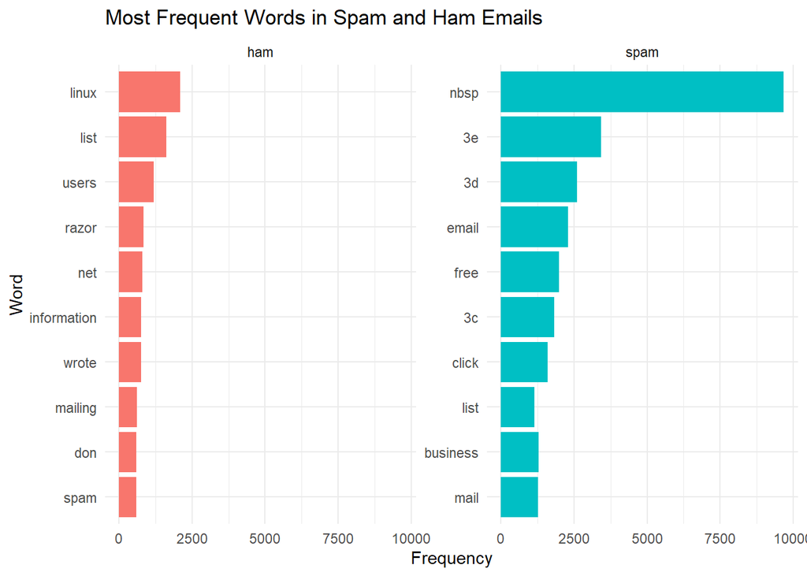

```r
email_words %>%
  count(label, word) %>%
  group_by(label) %>%
  slice_max(n, n = 10) %>%
  ggplot(aes(x = reorder(word, n), y = n, fill = label)) +
  geom_col() +
  coord_flip() +
  facet_wrap(~label, scales = "free_y") +
  labs(
    title = "Most Frequent Words in Spam and Ham Emails",
    x = "Word",
    y = "Frequency"
  ) +
  theme_minimal() +
  theme(legend.position = "none")
```

Ham emails frequently contain technology-related terms such as “linux” and “users”, while spam emails include words like “free”, “business”, and “click”. Some formatting artifacts remain, but the results already show differences in vocabulary between the two categories.

## Create a Document-Term Matrix

To prepare the text for classification, I will convert the words into a document-term matrix. This will show how frequently each word appears in each email, allowing the models to work with numerical data instead of raw text.

```r
dtm <- email_words %>%
  count(email_id, word) %>%
  cast_dtm(email_id, word, n)

dtm
```

```
<<DocumentTermMatrix (documents: 2793, terms: 48073)>>
Non-/sparse entries: 256471/134011418
Sparsity           : 100%
Maximal term length: 121
Weighting          : term frequency (tf)
```

Now i will match emails with matrix

```r
emails_model <- emails %>%
  mutate(email_id = row_number()) %>%
  filter(email_id %in% email_words$email_id)

nrow(emails_model)
```

```
[1] 2793
```

Before training the models, I will verify that the emails and document-term matrix are in the same order. This is important to ensure that each email is matched with the correct spam or ham label.

```r
identical(
  as.character(emails_model$email_id),
  rownames(as.matrix(dtm))
)
```

```
[1] TRUE
```

## Classification models

### Split data into training and testing sets

I will divide the emails into 80% training data and 20% testing data. I’ll use stratified sampling to keep similar proportions of spam and ham in both groups. The training set will be used to build the models, while the testing set will evaluate how well they classify new emails.

```r
library(rsample)

set.seed(123)

split <- initial_split(emails_model, prop = 0.8, strata = label)

train <- training(split)
test <- testing(split)

table(train$label)
```

```
 ham spam
1120 1114
```

```r
table(test$label)
```

```
 ham spam
 280  279
```

To avoid using information from the testing data during training, I will build the vocabulary using only the training emails. Both models will then use the same vocabulary for a fair comparison.

```r
train_words <- email_words %>%
  filter(email_id %in% train$email_id)

train_vocab <- train_words %>%
  distinct(word)

nrow(train_vocab)
```

```
[1] 37648
```

Some words appear in only a few emails and may not be useful for classification. I will keep words that appear in at least five training emails to reduce the number of features.

```r
train_vocab <- train_words %>%
  distinct(email_id, word) %>%
  count(word, name = "n_emails") %>%
  filter(n_emails >= 5)

nrow(train_vocab)
```

```
[1] 6601
```

Next, I will convert the training and testing emails into document-term matrices using the vocabulary selected from the training data. Each row represents an email, and each column represents a word. The values show how many times each word appears in an email.

```r
library(Matrix)

# Keep only words from the training vocabulary
model_words <- email_words %>%
  semi_join(train_vocab, by = "word") %>%
  count(email_id, word, name = "n")

# Create one sparse matrix for all emails
model_matrix <- sparseMatrix(
  i = match(model_words$email_id, emails_model$email_id),
  j = match(model_words$word, train_vocab$word),
  x = model_words$n,
  dims = c(nrow(emails_model), nrow(train_vocab)),
  dimnames = list(
    as.character(emails_model$email_id),
    train_vocab$word
  )
)

# Split into training and testing matrices
train_dtm <- model_matrix[as.character(train$email_id), ]
test_dtm <- model_matrix[as.character(test$email_id), ]

dim(train_dtm)
```

```
[1] 2234 6601
```

```r
dim(test_dtm)
```

```
[1]  559 6601
```

## Naive Bayes Model

I will start with a Naive Bayes model, a common method for spam detection. It uses word frequencies to estimate whether an email is more likely to be spam or ham. I will train the model using the training emails and their known labels.

```r
library(quanteda)
library(quanteda.textmodels)

# Convert the training matrix to quanteda format
train_dfm <- as.dfm(train_dtm)

# Train the Naive Bayes model
nb_model <- textmodel_nb(
  train_dfm,
  y = factor(train$label)
)

nb_model
```

```
Call:
textmodel_nb.dfm(x = train_dfm, y = factor(train$label))

 Distribution: multinomial ; priors: 0.5 0.5 ; smoothing value: 1 ; 2234 training documents;  fitted features.
```

After training the Naive Bayes model, I will use it to predict whether each email in the testing set is spam or ham. I will then compare these predictions with the actual labels to evaluate the model’s performance.

```r
# Convert the testing matrix to quanteda format
test_dfm <- as.dfm(test_dtm)

# Predict email labels
nb_predictions <- predict(nb_model, newdata = test_dfm)

# Compare actual and predicted labels
table(
  Actual = test$label,
  Predicted = nb_predictions
)
```

```
      Predicted
Actual ham spam
  ham  276    4
  spam   9  270
```

The Naive Bayes model correctly classified 546 out of 559 testing emails, achieving an accuracy of approximately 97.67%. Only 4 legitimate emails were incorrectly identified as spam, while 9 spam emails were classified as ham. These results suggest that Naive Bayes performs well on this dataset, although some spam messages still go undetected.

### Logistic Regression Model

I will train a Logistic Regression model to classify emails as spam or ham. Unlike Naive Bayes, Logistic Regression estimates the probability of an email being spam based on a combination of word features. I will use the same training and testing data to make the comparison fair.

```r
library(glmnet)

# Convert labels to 0 (ham) and 1 (spam)
train_y <- ifelse(train$label == "spam", 1, 0)

# Train logistic regression
set.seed(123)

lr_model <- cv.glmnet(
  train_dtm,
  train_y,
  family = "binomial",
  alpha = 0,
  nfolds = 5
)

lr_model
```

```
Call:  cv.glmnet(x = train_dtm, y = train_y, nfolds = 5, family = "binomial",      alpha = 0)

Measure: Binomial Deviance

    Lambda Index Measure       SE Nonzero
min  2.280   100  0.6418 0.008664    6601
1se  2.389    99  0.6498 0.009009    6601
```

I will use the trained Logistic Regression model to predict whether each testing email is spam or ham. I will classify emails with a predicted spam probability of at least 50% as spam and compare the predictions with the actual labels.

```r
# Predict the probability of spam
lr_prob <- predict(
  lr_model,
  newx = test_dtm,
  s = "lambda.min",
  type = "response"
)

# Convert probabilities into spam/ham labels
lr_predictions <- ifelse(lr_prob >= 0.5, "spam", "ham")

# Compare actual and predicted labels
table(
  Actual = test$label,
  Predicted = lr_predictions
)
```

```
      Predicted
Actual ham spam
  ham  278    2
  spam   9  270
```

The Logistic Regression model correctly classified 548 out of 559 testing emails, achieving an accuracy of 98.03%. It incorrectly classified only 2 legitimate emails as spam and missed 9 spam emails. Compared with Naive Bayes, Logistic Regression performed slightly better.

### Compare model perfomance

```r
# Function to calculate performance metrics
evaluate <- function(predicted) {
  actual <- test$label

  tp <- sum(actual == "spam" & predicted == "spam")
  fp <- sum(actual == "ham" & predicted == "spam")
  fn <- sum(actual == "spam" & predicted == "ham")

  accuracy <- mean(actual == predicted)
  precision <- tp / (tp + fp)
  recall <- tp / (tp + fn)
  f1 <- 2 * precision * recall / (precision + recall)

  round(c(accuracy, precision, recall, f1), 3)
}
comparison <- rbind(
  "Naive Bayes" = evaluate(as.vector(nb_predictions)),
  "Logistic Regression" = evaluate(as.vector(lr_predictions))
)

colnames(comparison) <- c("Accuracy", "Precision", "Recall", "F1")

comparison
```

```
                    Accuracy Precision Recall    F1
Naive Bayes            0.977     0.985  0.968 0.976
Logistic Regression    0.980     0.993  0.968 0.980
```

I will use a heatmap to compare the accuracy, precision, recall, and F1 scores of both models. The colors and values will make it easier to see how the models perform across different metrics and identify any differences between them.

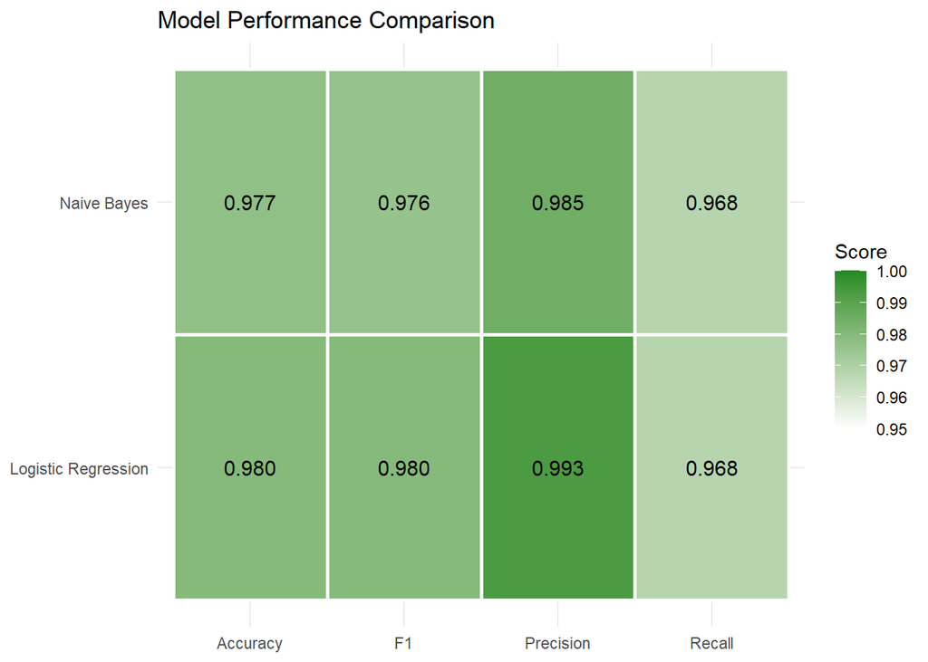

```r
library(tidyverse)
comparison %>%
  as.data.frame() %>%
  rownames_to_column("Model") %>%
  pivot_longer(
    cols = -Model,
    names_to = "Metric",
    values_to = "Score"
  ) %>%
  ggplot(aes(x = Metric, y = Model, fill = Score)) +
  geom_tile(color = "white", linewidth = 1) +
  geom_text(aes(label = sprintf("%.3f", Score)), size = 4) +
  scale_fill_gradient(
    low = "white",
    high = "forestgreen",
    limits = c(0.95, 1)
  ) +
  labs(
    title = "Model Performance Comparison",
    x = NULL,
    y = NULL
  ) +
  theme_minimal()
```

## Conclusion

In this project, I compared Naive Bayes and Logistic Regression to see how accurately they could classify emails as spam or ham based on their text.

Overall, the results show that both methods are effective for spam detection, with only a small difference in performance. One limitation was that some emails contained HTML formatting and encoded text that remained after cleaning. With more time, I would improve the text preprocessing, experiment with different classification thresholds, and test the models on other email datasets to see how well they perform on new data.

## AI Use Disclosure

I used ChatGPT throughout this project as a learning and coding assistant. It helped me understand more difficult concepts, particularly how Naive Bayes and Logistic Regression work, how they can be applied to text classification, and how to interpret performance metrics such as precision, recall, and F1 score. I also used ChatGPT to explore different approaches to text preprocessing and understand document-term matrices.